# Getting Started with ssdtools

ssdtools Team

2026-08-31

## Introduction

`ssdtools` is an R package to fit Species Sensitivity Distributions (SSDs) using Maximum Likelihood and model averaging.

SSDs are cumulative probability distributions that are used to estimate the percent of species that are affected and/or protected by a given concentration of a chemical. The concentration that affects 5% of the species is referred to as the 5% Hazard Concentration (*HC<sub>5</sub>*). This is equivalent to a 95% protection value (*PC<sub>95</sub>*). For more information on SSDs the reader is referred to Posthuma et al. (2001).

`ssdtools` can handle left, right and interval censored data with two limitations. It is currently only possible to model average when the distributions have the same number of parameters and confidence intervals can only be estimated using non-parametric (as opposed to parametric) bootstrapping.

In order to use `ssdtools` you need to install R (see below) or use the Shiny [app](https://bcgov-env.shinyapps.io/ssdtools/). The shiny app includes a user guide. This vignette is a user manual for the R package.

## Philosophy

`ssdtools` provides the key functionality required to fit SSDs using Maximum Likelihood and [model averaging](https://bcgov.github.io/ssdtools/articles/A_model_averaging.html) in R. It is intended to be used in conjunction with [tidyverse](https://tidyverse.org) packages such as `readr` to input data, `tidyr` and `dplyr` to group and manipulate data and `ggplot2` (Wickham 2016) to plot data. As such it endeavors to fulfill the tidyverse [manifesto](https://tidyverse.tidyverse.org/articles/manifesto.html).

## Installing

In order to install R (R Core Team 2024) the appropriate binary for the users operating system should be downloaded from [CRAN](https://cran.r-project.org) and then installed.

Once R is installed, the `ssdtools` package can be installed (together with the tidyverse) by executing the following code at the R console

```r
install.packages(c("ssdtools", "tidyverse"))
```

The `ssdtools` package (and ggplot2 package) can then be loaded into the current session using

```r
library(ssdtools)
library(ggplot2)
```

## Getting Help

To get additional information on a particular function just type `?` followed by the name of the function at the R console. For example `?ssd_gof` brings up the R documentation for the `ssdtools` goodness of fit function.

For more information on using R the reader is referred to [R for Data Science](https://r4ds.had.co.nz) (Wickham and Grolemund 2016).

If you discover a bug in `ssdtools` please file an issue with a [reprex](https://reprex.tidyverse.org/articles/reprex-dos-and-donts.html) (repeatable example) at https://github.com/bcgov/ssdtools/issues.

## Inputting Data

Once the `ssdtools` package has been loaded the next task is to input some data. An easy way to do this is to save the concentration data for a *single* chemical as a column called `Conc` in a comma separated file (`.csv`). Each row should be the sensitivity concentration for a separate species. If species and/or group information is available then this can be saved as `Species` and `Group` columns. The `.csv` file can then be read into R using the following

```r
data <- read_csv(file = "path/to/file.csv")
```

For the purposes of this manual we use the CCME dataset for boron from the [`ssddata`](https://github.com/open-AIMS/ssddata) package.

```r
ssddata::ccme_boron
```

```
#> # A tibble: 28 × 6
#>    Chemical Species                  Conc Group        Units Medium
#>    <chr>    <chr>                   <dbl> <fct>        <chr> <chr>
#>  1 Boron    Oncorhynchus mykiss       2.1 Fish         mg/L  Freshwater
#>  2 Boron    Ictalurus punctatus       2.4 Fish         mg/L  Freshwater
#>  3 Boron    Micropterus salmoides     4.1 Fish         mg/L  Freshwater
#>  4 Boron    Brachydanio rerio        10   Fish         mg/L  Freshwater
#>  5 Boron    Carassius auratus        15.6 Fish         mg/L  Freshwater
#>  6 Boron    Pimephales promelas      18.3 Fish         mg/L  Freshwater
#>  7 Boron    Daphnia magna             6   Invertebrate mg/L  Freshwater
#>  8 Boron    Opercularia bimarginata  10   Invertebrate mg/L  Freshwater
#>  9 Boron    Ceriodaphnia dubia       13.4 Invertebrate mg/L  Freshwater
#> 10 Boron    Entosiphon sulcatum      15   Invertebrate mg/L  Freshwater
#> # ℹ 18 more rows
```

## Fitting Distributions

The function `ssd_fit_dists()` inputs a data frame and fits one or more distributions. The user can specify a subset of the following 9 distributions. Please see the [distributions](https://bcgov.github.io/ssdtools/articles/B_distributions.html) and [model averaging](https://bcgov.github.io/ssdtools/articles/A_model_averaging.html) vignettes for more information regarding appropriate use of distributions and the use of model-averaged SSDs.

```r
ssd_dists_all()
```

```
#> [1] "burrIII3"      "gamma"         "gompertz"      "lgumbel"
#> [5] "llogis"        "llogis_llogis" "lnorm"         "lnorm_lnorm"
#> [9] "weibull"
```

using the `dists` argument.

```r
fits <- ssd_fit_dists(ssddata::ccme_boron, dists = c("llogis", "lnorm", "gamma"))
```

## Coefficients

The estimates for the various terms can be extracted using the tidyverse generic `tidy` function (or the base R generic `coef` function).

```r
tidy(fits)
```

```
#> # A tibble: 6 × 4
#>   dist   term           est    se
#>   <chr>  <chr>        <dbl> <dbl>
#> 1 llogis locationlog  2.63  0.248
#> 2 llogis scalelog     0.740 0.114
#> 3 lnorm  meanlog      2.56  0.235
#> 4 lnorm  sdlog        1.24  0.166
#> 5 gamma  scale       25.1   7.64
#> 6 gamma  shape        0.950 0.223
```

## Plots

It is generally more informative to plot the fits using the `autoplot` generic function (a wrapper on `ssd_plot_cdf()`). As `autoplot` returns a `ggplot` object it can be modified prior to plotting. For more information see the [customising plots](https://bcgov.github.io/ssdtools/articles/customising-plots.html) vignette.

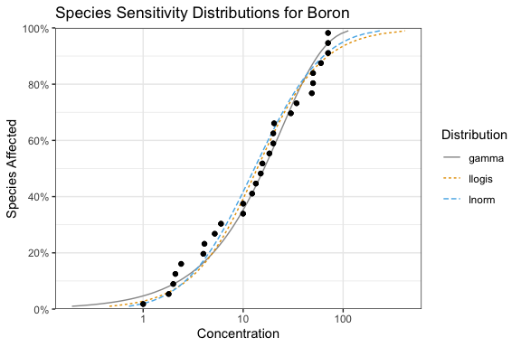

```r
theme_set(theme_bw()) # set plot theme

autoplot(fits) +
  ggtitle("Species Sensitivity Distributions for Boron") +
  scale_colour_ssd()
```

## Selecting One Distribution

Given multiple distributions the user is faced with choosing the “best” distribution (or as discussed below averaging the results weighted by the fit).

```r
ssd_gof(fits)
```

[output not shown]

The `ssd_gof()` function returns three test statistics that can be used to evaluate the fit of the various distributions to the data.

- [Anderson-Darling](https://en.wikipedia.org/wiki/Anderson%E2%80%93Darling_test) (`ad`) statistic,
- [Kolmogorov-Smirnov](https://en.wikipedia.org/wiki/Kolmogorov%E2%80%93Smirnov_test) (`ks`) statistic and
- [Cramer-von Mises](https://en.wikipedia.org/wiki/Cram%C3%A9r%E2%80%93von_Mises_criterion) (`cvm`) statistic

and three information criteria

- Akaike’s Information Criterion (`AIC`),
- Akaike’s Information Criterion corrected for sample size (`AICc`) and
- Bayesian Information Criterion (`BIC`)

Note if `ssd_gof()` is called with `pvalue = TRUE` then the p-values rather than the statistics are returned for the ad, ks and cvm tests.

Following Burnham and Anderson (2002) we recommend the `AICc` for model selection. The best predictive model is that with the lowest `AICc` (indicated by the model with a `delta` value of 0 in the goodness of fit table). In the current example the best predictive model is the gamma distribution but both the lnorm and llogis distributions have some support.

For further information on the advantages of an information theoretic approach in the context of selecting SSDs the reader is referred to Fox et al. (2021).

## Averaging Multiple Distributions

Often other distributions will fit the data almost as well as the best distribution as evidenced by `delta` values < 2 (Burnham and Anderson 2002). In general, the recommended approach is to estimate the average fit based on the relative weights of the distributions (Burnham and Anderson 2002). The `AICc` based weights are indicated by the `weight` column in the goodness of fit table. A detailed introduction to model averaging can be found in the [Model averaging](https://bcgov.github.io/ssdtools/articles/A_model_averaging.html) vignette. A discussion on the recommended set of default distributions can be found in the [Distributions](https://bcgov.github.io/ssdtools/articles/B_distributions.html) vignette.

## Estimating the Fit

The `predict` function can be used to generate model-averaged estimates (or if `average = FALSE` estimates for each distribution individual) by bootstrapping. Model averaging is based on `AICc` unless the data censored is which case `AICc` is undefined. In this situation model averaging is only possible if the distributions have the same number of parameters (so that `AIC` can be used to compare the models).

```r
withr::with_seed(99, {
  boron_pred <- predict(fits, ci = TRUE)
})
```

```r
boron_pred
```

```
#> # A tibble: 99 × 15
#>    dist    proportion   est    se    lcl   ucl    wt level est_method ci_method
#>    <chr>        <dbl> <dbl> <dbl>  <dbl> <dbl> <dbl> <dbl> <chr>      <chr>
#>  1 average       0.01 0.267 0.402 0.0419  1.53     1  0.95 multi      weighted_…
#>  2 average       0.02 0.531 0.518 0.110   2.03     1  0.95 multi      weighted_…
#>  3 average       0.03 0.783 0.615 0.198   2.50     1  0.95 multi      weighted_…
#>  4 average       0.04 1.02  0.701 0.300   2.89     1  0.95 multi      weighted_…
#>  5 average       0.05 1.26  0.782 0.407   3.29     1  0.95 multi      weighted_…
#>  6 average       0.06 1.48  0.859 0.520   3.72     1  0.95 multi      weighted_…
#>  7 average       0.07 1.71  0.934 0.645   4.16     1  0.95 multi      weighted_…
#>  8 average       0.08 1.93  1.01  0.769   4.58     1  0.95 multi      weighted_…
#>  9 average       0.09 2.16  1.08  0.896   4.95     1  0.95 multi      weighted_…
#> 10 average       0.1  2.38  1.15  1.03    5.33     1  0.95 multi      weighted_…
#> # ℹ 89 more rows
#> # ℹ 5 more variables: boot_method <chr>, nboot <dbl>, pboot <dbl>,
#> #   dists <list>, samples <list>
```

The data frame of the estimates can then be plotted together with the original data using the `ssd_plot()` function to summarize an analysis. Once again the returned object is a `ggplot` object which can be customized prior to plotting.

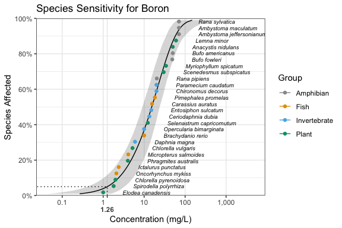

```r
ssd_plot(ssddata::ccme_boron, boron_pred,
  color = "Group", label = "Species",
  xlab = "Concentration (mg/L)", ribbon = TRUE
) +
  expand_limits(x = 5000) + # to ensure the species labels fit
  ggtitle("Species Sensitivity for Boron") +
  scale_colour_ssd()
```

In the above plot the model-averaged 95% confidence interval is indicated by the shaded band and the model-averaged 5%/95% Hazard/Protection Concentration (*HC5*/ *PC<sub>95</sub>*) by the dotted line. Hazard/Protection concentrations are discussed below.

## Hazard/Protection Concentrations

The 5% hazard concentration (*HC5*) is the concentration that affects 5% of the species tested. This is equivalent to the 95% protection concentration which protects 95% of species (*PC<sub>95</sub>*). The hazard and protection concentrations are directly interchangeable, and terminology depends simply on user preference.

The hazard/protection concentrations can be obtained using the `ssd_hc()` function, which can be used to obtain any desired percentage value. The fitted SSD can also be used to determine the percentage of species protected at a given concentration using `ssd_hp()`.

```r
withr::with_seed(99, {
  boron_hc5 <- ssd_hc(fits, proportion = 0.05, ci = TRUE)
  print(boron_hc5)
  boron_pc <- ssd_hp(fits, conc = boron_hc5$est, ci = TRUE)
  print(boron_pc)
})
```

[output not shown]

### Censored Data

Censored data is that for which only a lower and/or upper limit is known for a particular species. If the `right` argument in `ssd_fit_dists()` is different to the `left` argument then the data are considered to be censored.

Let’s produce some left censored data.

```r
boron_censored <- ssddata::ccme_boron |>
  dplyr::mutate(left = Conc, right = Conc)

boron_censored$left[c(3, 6, 8)] <- NA
```

As the sample size `n` is undefined for censored data, `AICc` cannot be calculated. However, if all the models have the same number of parameters, the `AIC` `delta` values are identical to those for `AICc`. For this reason, `ssdtools` only permits model averaging of censored data for distributions with the same number of parameters. We can call only the default two parameter models using `ssd_dists_bcanz(n = 2)`.

```r
dists <- ssd_fit_dists(boron_censored,
  dists = ssd_dists_bcanz(n = 2),
  left = "left", right = "right"
)
```

```r
ssd_gof(dists)
```

```
#> # A tibble: 5 × 14
#>   dist    npars  nobs log_lik   aic  aicc delta weight   bic    ad    ks   cvm
#>   <chr>   <int> <int>   <dbl> <dbl> <dbl> <dbl>  <dbl> <dbl> <dbl> <dbl> <dbl>
#> 1 gamma       2    NA   -109.  222.    NA 0      0.376    NA    NA    NA    NA
#> 2 lgumbel     2    NA   -112.  228.    NA 5.67   0.022    NA    NA    NA    NA
#> 3 llogis      2    NA   -111.  226.    NA 3.70   0.059    NA    NA    NA    NA
#> 4 lnorm       2    NA   -110.  224.    NA 1.52   0.176    NA    NA    NA    NA
#> 5 weibull     2    NA   -109.  222.    NA 0.046  0.367    NA    NA    NA    NA
#> # ℹ 2 more variables: at_bound <lgl>, computable <lgl>
```

The model-averaged predictions are calculated using `AIC`

```r
ssd_hc(dists, average = FALSE)
```

```
#> # A tibble: 5 × 15
#>   dist    proportion   est    se   lcl   ucl     wt level est_method ci_method
#>   <chr>        <dbl> <dbl> <dbl> <dbl> <dbl>  <dbl> <dbl> <chr>      <chr>
#> 1 gamma         0.05 0.674    NA    NA    NA 0.376   0.95 cdf        percentile
#> 2 lgumbel       0.05 1.51     NA    NA    NA 0.0221  0.95 cdf        percentile
#> 3 llogis        0.05 1.15     NA    NA    NA 0.0590  0.95 cdf        percentile
#> 4 lnorm         0.05 1.32     NA    NA    NA 0.176   0.95 cdf        percentile
#> 5 weibull       0.05 0.752    NA    NA    NA 0.367   0.95 cdf        percentile
#> # ℹ 5 more variables: boot_method <chr>, nboot <int>, pboot <dbl>,
#> #   dists <list>, samples <list>
```

```r
ssd_hc(dists)
```

```
#> # A tibble: 1 × 15
#>   dist    proportion   est    se   lcl   ucl    wt level est_method ci_method
#>   <chr>        <dbl> <dbl> <dbl> <dbl> <dbl> <dbl> <dbl> <chr>      <chr>
#> 1 average       0.05 0.859    NA    NA    NA     1  0.95 multi      weighted_sa…
#> # ℹ 5 more variables: boot_method <chr>, nboot <int>, pboot <dbl>,
#> #   dists <list>, samples <list>
```

The confidence intervals can currently only be generated for censored data using non-parametric bootstrapping. The horizontal lines in the plot indicate the censoring (range of possible values).

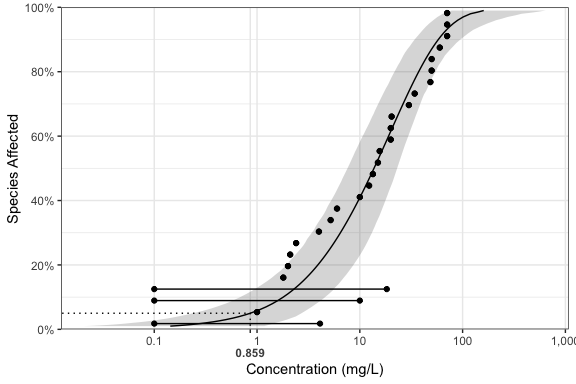

```r
withr::with_seed(99, {
  pred <- predict(dists, ci = TRUE, parametric = FALSE)
})

ssd_plot(boron_censored, pred,
  left = "left", right = "right",
  xlab = "Concentration (mg/L)"
)
```

## References

Burnham, Kenneth P., and David R. Anderson, eds. 2002. *Model Selection and Multimodel Inference*. Springer New York. https://doi.org/10.1007/b97636.

Fox, D. R., R. A. Dam, R. Fisher, et al. 2021. “Recent Developments in Species Sensitivity Distribution Modeling.” *Environmental Toxicology and Chemistry* 40 (2): 293–308. https://doi.org/10.1002/etc.4925.

Posthuma, Leo, Glenn W Suter II, and Theo P Traas. 2001. *Species Sensitivity Distributions in Ecotoxicology*. CRC press. https://www.routledge.com/Species-Sensitivity-Distributions-in-Ecotoxicology/Posthuma-II-Traas/p/book/9781566705783.

R Core Team. 2024. *R: A Language and Environment for Statistical Computing*. R Foundation for Statistical Computing. https://www.R-project.org/.

Wickham, Hadley. 2016. *ggplot2: Elegant Graphics for Data Analysis*. Springer-Verlag New York. https://ggplot2.tidyverse.org.

Wickham, Hadley, and Garrett Grolemund. 2016. *R for Data Science: Import, Tidy, Transform, Visualize, and Model Data*. First edition. O’Reilly. https://r4ds.had.co.nz.

## Licensing

Copyright 2015-2023 Province of British Columbia  
Copyright 2021 Environment and Climate Change Canada  
Copyright 2023-2025 Australian Government Department of Climate Change, Energy, the Environment and Water

The documentation is released under the [CC BY 4.0 License](https://creativecommons.org/licenses/by/4.0/)

The code is released under the [Apache License 2.0](https://www.apache.org/licenses/LICENSE-2.0)